# HW2[김수빈]

## (e)

```r
# Split the sample into two parts: estimation sample from 1975M1 to 2014M12, and the prediction sample from 2015M1 to 2018M12

dd12lE1 <- window(dd12lE, start=1976 +(2/12), end = 2014, frequency=12)
dd12lE2 <-window(dd12lE, start=2015, end = 2018, frequency=12)
```

```r
# Use ACF and PACF from (c) to identify and estimate a suitable model for dd12lE using arima

m1 <- arima(dd12lE1, order=c(1,0,0), seasonal=list(order=c(1,0,1), period = 12))

m1
```

```
##
## Call:
## arima(x = dd12lE1, order = c(1, 0, 0), seasonal = list(order = c(1, 0, 1), period = 12))
##
## Coefficients:
##          ar1    sar1     sma1  intercept
##       0.5320  0.1805  -0.8288      0e+00
## s.e.  0.0421  0.0610   0.0330      1e-04
##
## sigma^2 estimated as 3.384e-06:  log likelihood = 2214.72,  aic = -4419.43
```

```r
m2 <- arima(dd12lE1, order=c(2,0,0), seasonal=list(order=c(1,0,1), period = 12))

m2
```

```
##
## Call:
## arima(x = dd12lE1, order = c(2, 0, 0), seasonal = list(order = c(1, 0, 1), period = 12))
##
## Coefficients:
##          ar1     ar2    sar1     sma1  intercept
##       0.3424  0.3802  0.1414  -0.8071      0e+00
## s.e.  0.0441  0.0442  0.0610   0.0334      1e-04
##
## sigma^2 estimated as 2.913e-06:  log likelihood = 2248.92,  aic = -4485.83
```

```r
m3 <- arima(dd12lE1, order=c(3,0,0), seasonal=list(order=c(1,0,1), period = 12))

m3
```

```
##
## Call:
## arima(x = dd12lE1, order = c(3, 0, 0), seasonal = list(order = c(1, 0, 1), period = 12))
##
## Coefficients:
##          ar1     ar2     ar3    sar1     sma1  intercept
##       0.2592  0.3104  0.2135  0.1337  -0.8243      0e+00
## s.e.  0.0469  0.0460  0.0478  0.0593   0.0318      1e-04
##
## sigma^2 estimated as 2.784e-06:  log likelihood = 2258.68,  aic = -4503.36
```

Based on AIC, model 3, ARIMA(3,0,0)(1,0,1)[12] is the best model.

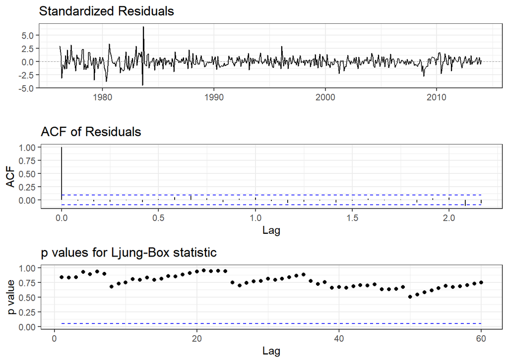

```r
# Diagnose residuals

ggtsdiag(m3, gof.lag = 60)
```

## (f)

```r
# Find the best model for lE using auto.arima

lE1 <-window(lE, start=1975, end = 2014, frequency=12)

m4 <- auto.arima(lE1, ic="aic", seasonal=TRUE, stationary=TRUE, stepwise=FALSE, approximation=FALSE)

m4
```

```
## Series: lE1
## ARIMA(1,0,4) with non-zero mean
##
## Coefficients:
##          ar1     ma1     ma2     ma3     ma4        mean
##       0.9670  1.0062  1.2162  1.0003  0.8591  112250.494
## s.e.  0.0118  0.0305  0.0360  0.0273  0.0275    6725.524
##
## sigma^2 = 1024839:  log likelihood = -3914.34
## AIC=7842.67   AICc=7842.91   BIC=7871.73
```

Based on the auto.arima, ARIMA(1,0,4) is the best model.

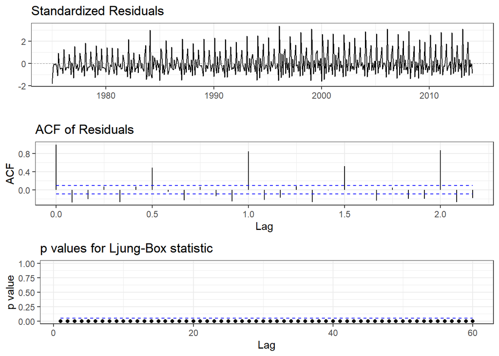

```r
# Diagnose residuals

ggtsdiag(m4, gof.lag = 60)
```

## (g)

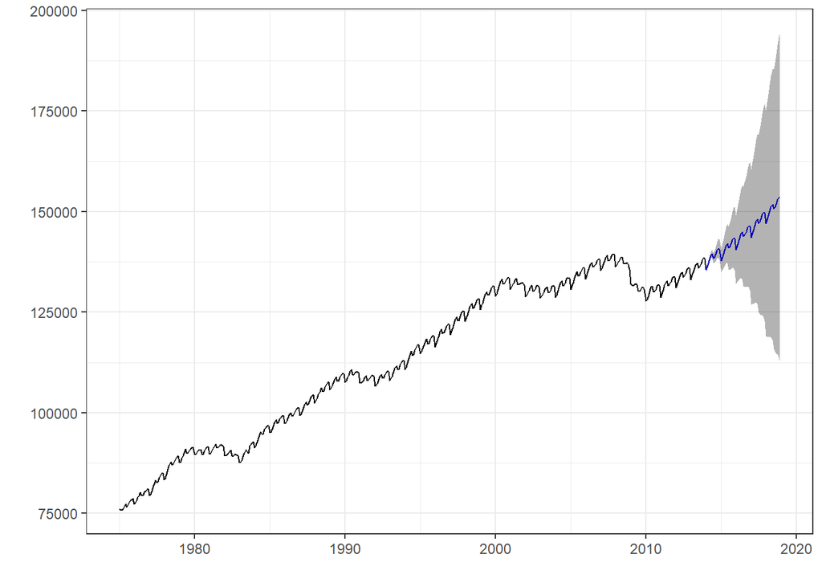

```r
# Create a rolling scheme sequence of 1 period ahead forecasts for the prediction subsample 2015M1-2018M12 using the same model specification as in (f)

m5 <- arima(lE1, order=c(1,2,1), seasonal=list(order=c(2,1,1), period = 12))

end <- 2014

forecasting.length <- window(lE, start = end + (1/12))

m5.f.h <- forecast(m5, length(forecasting.length))

autoplot(m5.f.h)
```

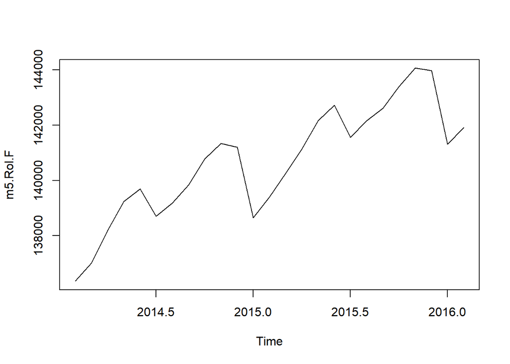

```r
lE2 <-window(lE, start=2015, end = 2017, frequency=12)

m5.Rol.F <- zoo()

fstQ <- 1975

lstQ <- 2014

for(i in 1:length(lE2)) {
  temp <- window(lE, start=fstQ + (i-1)/12, end = lstQ + (i-1)/12)
  m5.update <- arima(temp, order = c(1,2,1), seasonal = list(order = c(2,1,1), period = 12))
  m5.Rol.F <- c(m5.Rol.F, forecast(m5.update, 1)$mean)
}

m5.Rol.F <- as.ts(m5.Rol.F)

plot(m5.Rol.F)
```

## (h)

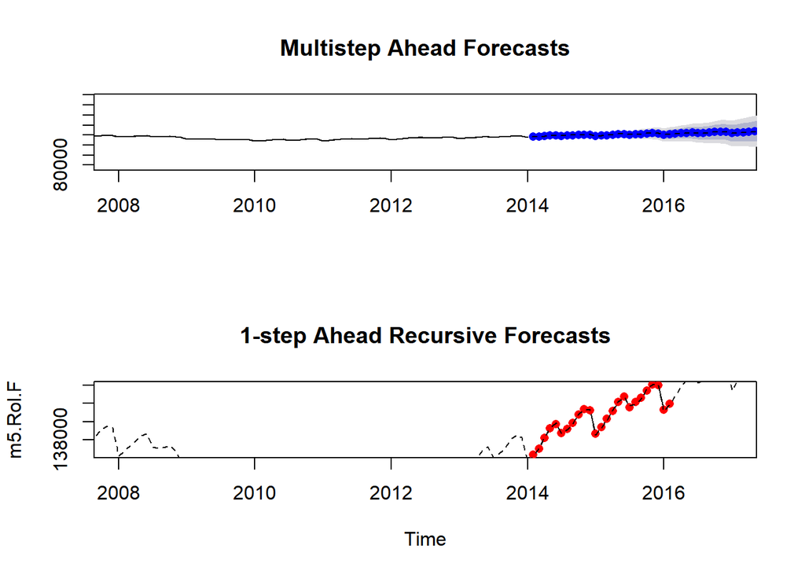

```r
# Plot the forecast for E from (g) together with its confidence intervals and the actual data for the period 2008M1-2018M12

par(mfrow=c(2,1))

plot(m5.f.h, xlim=c(2008,2017), main="Multistep Ahead Forecasts")
lines(m5.f.h$mean, type="p", pch=16, lty="dashed", col="blue")
lines(lE, pch=16, lty="dashed")

plot(m5.Rol.F, xlim=c(2008,2017), main = "1-step Ahead Recursive Forecasts")
lines(m5.Rol.F, type="p", pch=16, lty="solid", col="red")
lines(lE,pch=16, lty="dashed")
```

## (i)

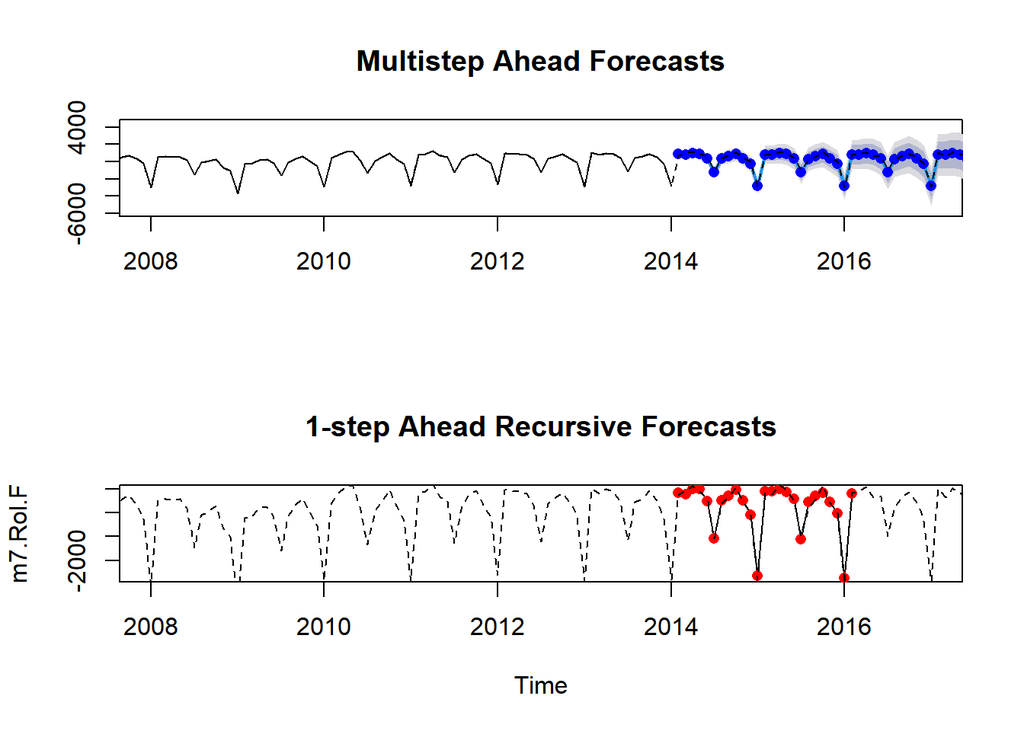

```r
# Use the forecast for Et from (g) to construct the forecast for dE, plot it together with the actual data

dE <- ts(TNPE$dE, start=1975, frequency=12)

dE1 <-window(dE, start=1975, end = 2014, frequency=12)
dE2 <-window(dE, start=2015, end = 2017, frequency=12)

m6 <- auto.arima(dE1, ic="aic", seasonal=TRUE, stationary=TRUE, stepwise=FALSE, approximation=FALSE)
m7 <- arima(dE1, order=c(1,2,1), seasonal=list(order=c(2,1,1), period = 12))

# Multistep Ahead Forecast

end <- 2014

forecasting.length <- window(dE, start = end + (1/12))

m7.f.h <- forecast(m7, length(forecasting.length))

# 1-step Ahead Recursive Forecast

m7.Rol.F <- zoo()

fstQ <- 1975
lstQ <- 2014

for(i in 1:length(dE2)) {
  temp <- window(dE, start=fstQ + (i-1)/12, end = lstQ + (i-1)/12)
  m7.update <- arima(temp, order = c(1,2,1), seasonal = list(order = c(2,1,1), period = 12))
  m7.Rol.F <- c(m7.Rol.F, forecast(m7.update, 1)$mean)
}

m7.Rol.F <- as.ts(m7.Rol.F)

# Plot

par(mfrow=c(2,1))

plot(m7.f.h, xlim=c(2008,2017), main="Multistep Ahead Forecasts")
lines(m7.f.h$mean, type="p", pch=16, lty="dashed", col="blue")
lines(dE, pch=16, lty="dashed")

plot(m7.Rol.F, xlim=c(2008,2017), main = "1-step Ahead Recursive Forecasts")
lines(m7.Rol.F, type="p", pch=16, lty="solid", col="red")
lines(dE,pch=16, lty="dashed")
```

## (j)

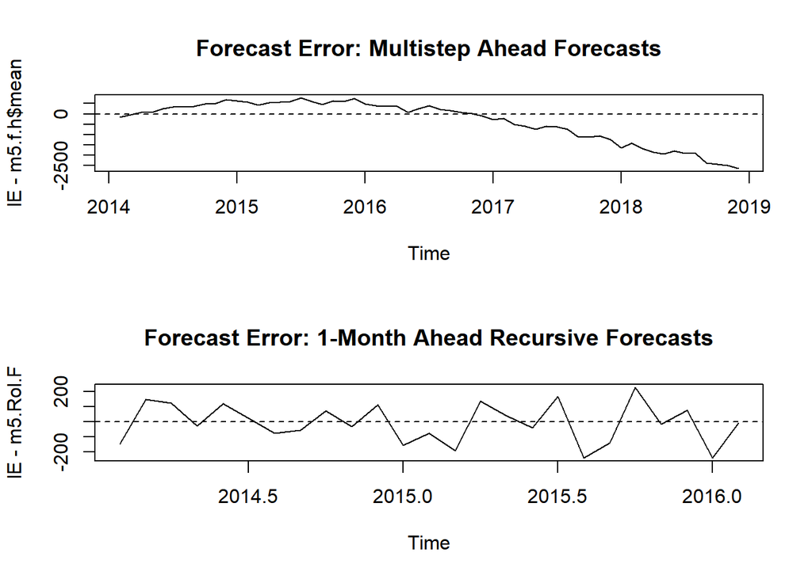

```r
# Forecast error for E

par(mfrow=c(2,1))

plot(lE - m5.f.h$mean, main = "Forecast Error: Multistep Ahead Forecasts")
abline(h=0, lty="dashed")

plot(lE - m5.Rol.F, main = "Forecast Error: 1-Month Ahead Recursive Forecasts")
abline(h=0, lty="dashed")
```

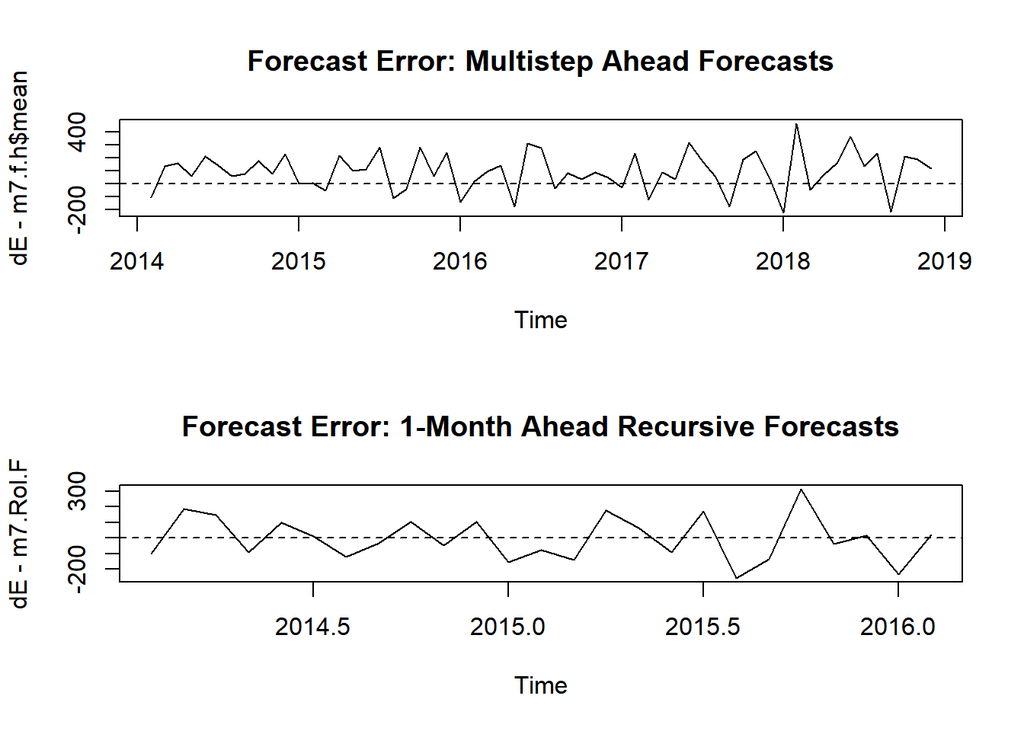

```r
# Forecast error for E

par(mfrow=c(2,1))

plot(dE - m7.f.h$mean, main = "Forecast Error: Multistep Ahead Forecasts")
abline(h=0, lty="dashed")

plot(dE - m7.Rol.F, main = "Forecast Error: 1-Month Ahead Recursive Forecasts")
abline(h=0, lty="dashed")
```

# Question 3

```r
# Obtain the two following time series: labor productivity and total hours worked

lpo<-Quandl("FRED/OPHNFB", type="zoo")
twho<-Quandl("FRED/HOANBS", type="zoo")

lp<-window(lpo,start="1947 Q1", end="2017 Q4")
twh<-window(twho,start="1947 Q1", end="2017 Q4")
```

## (a)

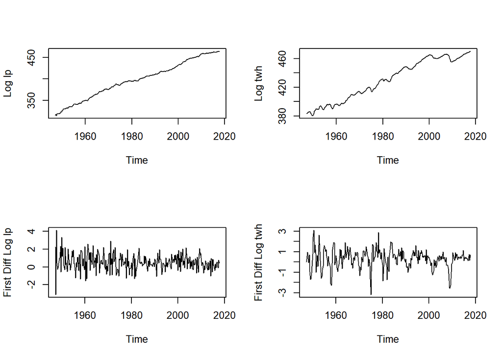

```r
# log of lp and twh

llp<-log(lp)*100
ltwh<-log(twh)*100

# first differences
dllp<-diff(llp,1)
dltwh<-diff(ltwh,1)

par(mfrow=c(2,2))
plot(llp,xlab="Time", ylab="Log lp")
plot(ltwh,xlab="Time", ylab="Log twh")
plot(dllp,xlab="Time", ylab="First Diff Log lp")
plot(dltwh,xlab="Time", ylab="First Diff Log twh")
```

```r
# ADF test of llp

adf.test(llp)
```

```
##
##  Augmented Dickey-Fuller Test
##
## data:  llp
## Dickey-Fuller = -2.3352, Lag order = 6, p-value = 0.4349
## alternative hypothesis: stationary
```

```r
# ADF test of ltwh

adf.test(ltwh)
```

```
##
##  Augmented Dickey-Fuller Test
##
## data:  ltwh
## Dickey-Fuller = -1.974, Lag order = 6, p-value = 0.5871
## alternative hypothesis: stationary
```

```r
# ADF unit root test of dllp

adf.test(dllp)
```

```
##
##  Augmented Dickey-Fuller Test
##
## data:  dllp
## Dickey-Fuller = -6.8656, Lag order = 6, p-value = 0.01
## alternative hypothesis: stationary
```

```r
# ADF unit root test of dltwh

adf.test(dltwh)
```

```
##
##  Augmented Dickey-Fuller Test
##
## data:  dltwh
## Dickey-Fuller = -6.0531, Lag order = 6, p-value = 0.01
## alternative hypothesis: stationary
```

It can be concluded that the log variables have a unit root. Meanwhile, since the p-value of the ADF unit root test for the first differences is less than 0.05, we can reject that there is a unit root for the first differences of the log of labor productivity (lp) and total hours worked (twh).

## (b)

```r
# Estimate a bivariate reduced form VAR using AIC information criteria to select number of lags

y<-cbind(dllp,dltwh)
y<-na.trim(y)
y<-sweep(y,2,apply(y,2,mean))
VARselect(y,lag.max=8)
```

```
## $selection
## AIC(n)  HQ(n)  SC(n) FPE(n)
##      3      2      2      3
##
## $criteria
##                1          2          3          4          5          6
## AIC(n) -1.123037 -1.1989704 -1.2005966 -1.1801031 -1.1760153 -1.1570765
## HQ(n)  -1.091368 -1.1461881 -1.1267013 -1.0850949 -1.0598941 -1.0198425
## SC(n)  -1.044126 -1.0674515 -1.0164700 -0.9433689 -0.8866736 -0.8151273
## FPE(n)  0.325291  0.3015069  0.3010212  0.3072614  0.3085320  0.3144483
##                 7          8
## AIC(n) -1.1285784 -1.1484876
## HQ(n)  -0.9702314 -0.9690277
## SC(n)  -0.7340215 -0.7013231
## FPE(n)  0.3235630  0.3172162
```

```r
# lag 3 has the lowest AIC

var1<-VAR(y,p=3, type="const")
summary(var1)
```

```
##
## VAR Estimation Results:
## =========================
## Endogenous variables: dllp, dltwh
## Deterministic variables: const
## Sample size: 280
## Log Likelihood: -612.98
## Roots of the characteristic polynomial:
## 0.7289 0.7289 0.4231 0.4231 0.3997 0.3997
## Call:
## VAR(y = y, p = 3, type = "const")
##
##
## Estimation results for equation dllp:
## =====================================
## dllp = dllp.l1 + dltwh.l1 + dllp.l2 + dltwh.l2 + dllp.l3 + dltwh.l3 + const
##
##           Estimate Std. Error t value Pr(>|t|)
## dllp.l1  -0.084897   0.058654  -1.447  0.14893
## dltwh.l1  0.064392   0.070347   0.915  0.36082
## dllp.l2   0.061674   0.055465   1.112  0.26715
## dltwh.l2 -0.190677   0.083012  -2.297  0.02238 *
## dllp.l3  -0.003087   0.054670  -0.056  0.95502
## dltwh.l3 -0.198458   0.072270  -2.746  0.00643 **
## const    -0.005431   0.047303  -0.115  0.90868
## ---
## Signif. codes:  0 '***' 0.001 '**' 0.01 '*' 0.05 '.' 0.1 ' ' 1
##
##
## Residual standard error: 0.7915 on 273 degrees of freedom
## Multiple R-Squared:  0.12,   Adjusted R-squared: 0.1007
## F-statistic: 6.207 on 6 and 273 DF,  p-value: 4.003e-06
##
##
## Estimation results for equation dltwh:
## ======================================
## dltwh = dllp.l1 + dltwh.l1 + dllp.l2 + dltwh.l2 + dllp.l3 + dltwh.l3 + const
##
##           Estimate Std. Error t value Pr(>|t|)
## dllp.l1   0.110468   0.050526   2.186   0.0296 *
```

[output cut: 10 more lines]

```
## Residual standard error: 0.6818 on 273 degrees of freedom
## Multiple R-Squared: 0.4316,  Adjusted R-squared: 0.4191
## F-statistic: 34.55 on 6 and 273 DF,  p-value: < 2.2e-16
##
##
##
## Covariance matrix of residuals:
##          dllp   dltwh
## dllp  0.62643 0.06116
## dltwh 0.06116 0.46485
##
## Correlation matrix of residuals:
##         dllp  dltwh
## dllp  1.0000 0.1133
## dltwh 0.1133 1.0000
```